# bioplots

**Visualization of Overlapping Results with Heatmap**

Visualization of complex biological datasets is essential to understand complementary spects of biology in big data era. Analization of multiple datasets enables to understand biologcal process deeply and accurately. Multiple datasets produce multiple analysis results, and these overlapping results are usually visualized in Venn diagram. bioplots is a tiny R package that generates heatmap to visualize overlapping results instead of using Venn diagram.

## Installation

bioplots package is available on CRAN repository. It can be installed with `install.package` function.

```r
install.packages("bioplots")
```

## Usage

bioplots provides some plotting functions to generate figure from datasets. Functions in bioplots package can be listed up using `ls` function.

```r
library(bioplots)
ls("package:bioplots")
```

```
## [1] "heatmap.overlaps"
```

### HeatmapOverlaps

`heatmap.overlaps` function generates heatmap to visualize overlapping results. Generally, overlapping results are visualized in Vennn diagrams. However, complex biological datasets usually give multiple Venn diagrams, and it complicates to interpret. `heatmap.overlaps` plots multiple Venn diagrams on one heatmap.

`heatmap.overlaps` expects list object and matrix object as input data. The list object should be two-level as well as the second level lists should contain element sets corresponding to each cluster. Otherwise, if matrix object is given, row names should be the combination of overlap patterns, and column names should be the conditions.

#### List Object

A example with the given list object.

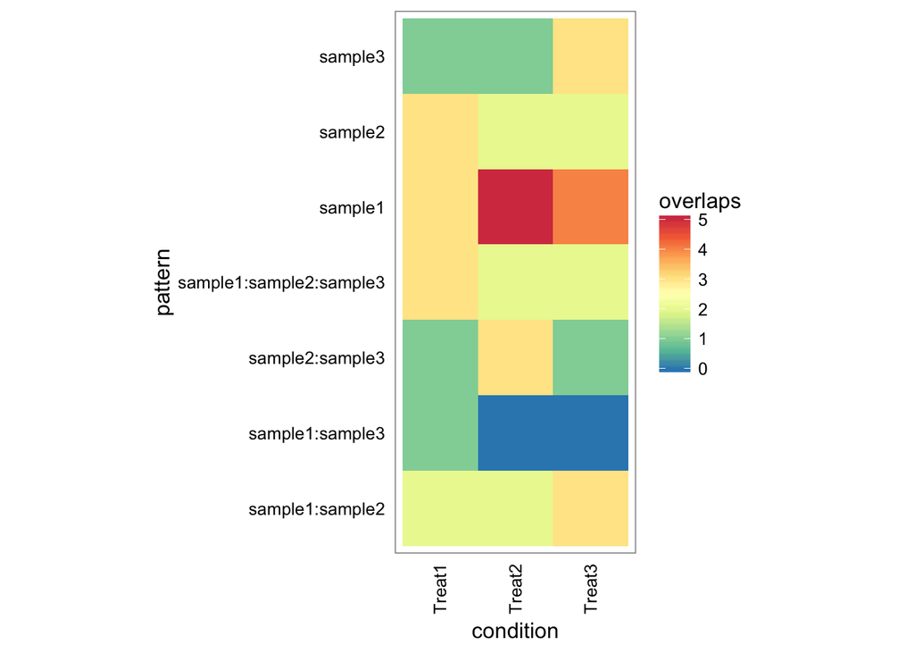

```r
treat1 <- list(sample1 = c("KDR", "CUL3A", "RNS3", "DD46", "SHM6", "GLYR2", "NOF1", "PGDH", "WBC11"),
               sample2 = c("KDR", "CUL3A", "DD46", "GLYR2", "NOF1", "ATCCMH", "DET3", "ATRBL6", "STP1"),
               sample3 = c("KDR", "CUL3A", "RNS3", "NOF1", "ATCCMH", "SNL6"))
treat2 <- list(sample1 = c("KDR", "CUL3A", "RNS3", "LEC1", "SHM6", "GLYR2", "NOF1", "PGDH", "LYM1"),
               sample2 = c("KDR", "CUL3A", "DD46", "LEC1", "NOF1", "ATCCMH", "DET3", "ATRBL6", "STP1"),
               sample3 = c("KDR", "LEC1", "DET3", "STP1", "ATCCMH", "SNL6"))
treat3 <- list(sample1 = c("KDR", "CUL3A", "RNS3", "LEC1", "SHM6", "GLYR2", "ZFP6", "CLPP3", "GAD2"),
               sample2 = c("KDR", "CUL3A", "DD46", "LEC1", "NOF1", "ATCCMH", "ZFP6", "GAD2"),
               sample3 = c("KDR", "LEC1", "DET3", "STP1", "NOF1", "SK42"))
dat.list <- list(Treat1 = treat1, Treat2 = treat2, Treat3 = treat3)

heatmap.overlaps(dat.list)
```

#### Matrix Object

A exmaple with the given matrix object.

```r
mat <- matrix(rnbinom(135, size = 10, prob = 0.2), nrow = 15, ncol = 9)
colnames(mat) <- paste0("Treat", 1:9)
rownames(mat) <- c("a", "b", "c", "d", "ab", "ac", "ad", "bc", "bd", "cd",
                   "abc", "abd", "acd", "bcd", "abcd")
head(mat)
```

```
##    Treat1 Treat2 Treat3 Treat4 Treat5 Treat6 Treat7 Treat8 Treat9
## a      18     47     50     31     31     24     70     16     35
## b      42     51     59     35     36     54     29     35     24
## c      27     16     40     37     30     41     13     42     57
## d      49     17     30     51     57     22     14     83     35
## ab     36     58     49     21     47     70     70     39     43
## ac     20     43     39     59     45     73     71     31     30
```

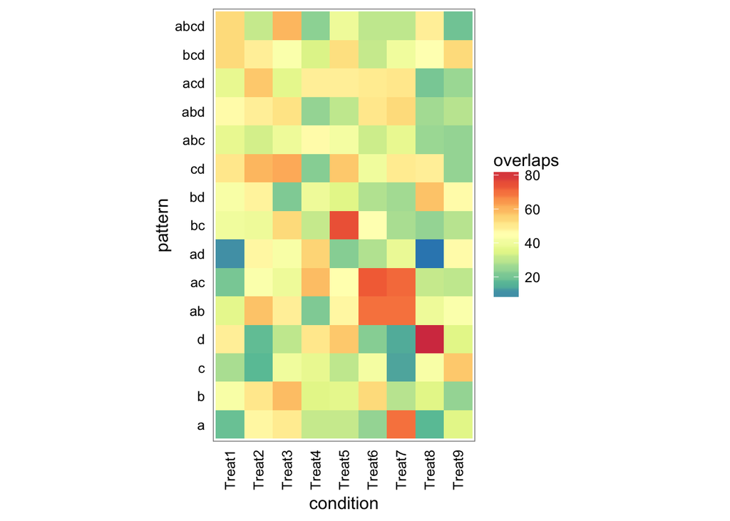

```r
heatmap.overlaps(mat)
```